# glober package

Mary E. Savino

# Introduction

The package \textsf{glober} provides two tools to estimate the function \(f\) in the following nonparametric regression model: \begin{equation} \label{eq:model} Y_i = f(x_i) + \varepsilon_i, \quad 1 \leq i \leq n, \end{equation} where the \(\varepsilon_i\) are i.i.d centered random variables of variance \(\sigma^2\), the \(x_i\) are observation points which belong to a compact set \(S\) of \(\mathbb{R}^d\), \(d=1\) or 2 and \(n\) is the total number of observations. This estimation is performed using the GLOBER approach described in [1]. This method consists in estimating \(f\) by approximating it with a linear combination of B-splines, where their knots are selected adaptively using the Generalized Lasso proposed by [2], since they can be seen as changes in the derivatives of the function to estimate. We refer the reader to [1] for further details.

# Estimation of \(f\) in the one-dimensional case ($d=1$)

In the following, we apply our method to a function of one input variable \(f_1\). This function is defined as a linear combination of quadratic B-splines with the set of knots \(\mathbf{t} = (0.1, 0.27,0.745)\) and \(\sigma = 0.1\) in \eqref{eq:model}.

## Description of the dataset

We load the dataset of observations with \(n=70\) provided within the package \((x_1, \ldots, x_{70})\):

```r
## --- Loading the values of the input variable --- ##
data('x_1D')
```

and \((Y_1, \ldots, Y_{70})\):

```r
## --- Loading the corresponding noisy values of the response variable --- ##
data('y_1D')
```

We load the dataset containing the values of the input variable \(\{x_1, \ldots, x_N\}\) for which an estimation of \(f_1\) is sought. They correspond to the observation points as well as additional points where \(f_1\) has not been observed. Here, \(N = 201\). In order to have a better idea of the underlying function \(f_1\), we load the corresponding evaluations of \(f_1\) at these input values.

```r
## --- Loading the values of the input variable for which an estimation
## of f_1 is required --- ##
data('xpred_1D')
## --- Loading the corresponding evaluations to plot the function --- ##
data('f_1D')
```

[figure not shown]

```r
## -- Building dataframes to plot -- ##
data_1D = data.frame(x = xpred_1D, f = f_1D)
obs_1D = data.frame(x = x_1D, y = y_1D)
real.knots = c(0.1, 0.27,0.745)
```

## Application of \(\texttt{glober.1d}\) to estimate \(f_1\)

The \(\texttt{glober.1d}\) function of the \(\texttt{glober}\) package is applied by using the following arguments: the input values \((x_i)_{1 \leq i \leq n}\) ($\texttt{x}$), the corresponding \((Y_i)_{1 \leq i \leq n}\) ($\texttt{y}$), \(N\) input values \(\{x_1, \ldots, x_N\}\) for which \(f_1\) has to be estimated ($\texttt{xpred}$) and the order of the B-spline basis used to estimate \(f_1\) ($\texttt{ord}$).

```r
res = glober.1d(x = x_1D, y = y_1D, xpred = xpred_1D, ord = 3, parallel = FALSE)
```

Additional arguments can also be used in this function:

- \(\texttt{parallel}\): Logical, if set to TRUE then a parallelized version of the code is used. The default value is FALSE.
- \(\texttt{nb.Cores}\): Numerical, it represents the number of cores used for parallelization, if parallel is set to TRUE.

The resulting outputs are the following:

- \(\texttt{festimated}\): the estimated values of \(f_1\).
- \(\texttt{knotSelec}\): the selected knots used in the definition of the B-splines of the GLOBER estimator.
- \(\texttt{rss}\): Residual sum-of-squares (RSS) of the model defined as: \(\sum_{k=1}^n (Y_i - \widehat{f_1}(x_i))^2\), where \(\widehat{f_1}\) is the estimator of \(f_1\).
- \(\texttt{rsq}\): R-squared of the model, calculated as \(1 - RSS/TSS\) where TSS is the total sum-of-squares of the model defined as \(\sum_{k=1}^n (Y_i - \bar{Y})^2\) with \(\bar{Y} = (\sum_{i=1}^n Y_i)/n\).

Thus, we can print the estimated values corresponding to the input values \(\{x_1, \ldots, x_N\}\):

```r
fhat = res$festimated
head(fhat)
```

```
## [1] -0.02579931 -0.26804301 -0.49284982 -0.70021972 -0.89015272 -1.06264882
```

The value of the Residual Sum-of-square:

```r
res$rss
```

[output not shown]

The value of the R-squared:

```r
res$rsq
```

```
## [1] 0.9970843
```

We can get the set of the estimated knots \(\mathbf{\widehat{t}}\):

```r
knots.set = res$Selected.knots
print(knots.set)
```

```
##  [1] 0.100 0.155 0.235 0.275 0.435 0.545 0.680 0.705 0.775 0.780 0.790 0.890
```

Finally, we can display the estimation of \(f_1\) by using the \(\texttt{ggplot2}\) package:

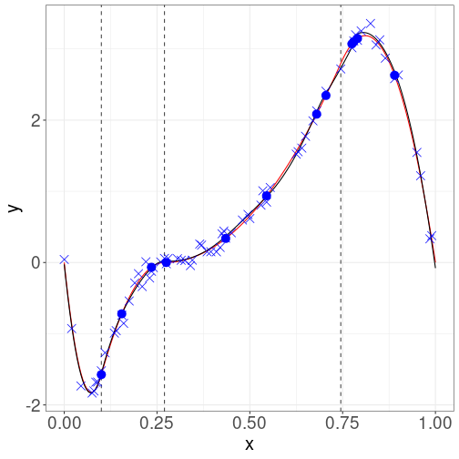

```r
## Dataframe of selected knots ##
idknots = which(xpred_1D %in% knots.set)
yknots = f_1D[idknots]
data_knots = data.frame(x.knots = knots.set, y.knots = yknots)
## Dataframe of the estimation ##
data_res = data.frame(xpred = xpred_1D, fhat = fhat)

plot_1D = ggplot(data_1D, aes(xpred_1D, f_1D)) +
    geom_line(color = 'red') +
    geom_line(data = data_1D, aes(x = xpred_1D, y = fhat), color = "black") +
    geom_vline(xintercept = real.knots, linetype = 'dashed', color = 'grey27') +
    geom_point(aes(x, y), data = obs_1D, shape = 4, color = "blue", size = 4)+
    geom_point(aes(x.knots, y.knots), data = data_knots, shape = 19, color = "blue",
               size = 4)+
    xlab('x') +
    ylab('y') +
    theme_bw()+
    theme(axis.title.x = element_text(size = 20), axis.title.y = element_text(size = 20),
          axis.text.x = element_text(size = 19),
          axis.text.y = element_text(size = 19))
plot_1D
```

The vertical dashed lines represent the real knots \(\mathbf{t}\) implied in the definition of \(f_1\), the red curve describes the true underlying function \(f_1\) to estimate, the black curve corresponds to the estimation with GLOBER, the blue crosses are the observation points and the blue bullets are the observation points chosen as estimated knots \(\widehat{t}\).

# Estimation of \(f\) in the two-dimensional case ($d=2$)

In the following, we apply our method to a function of two input variables \(f_2\). This function is defined as a linear combination of tensor products of quadratic univariate B-splines with the sets of knots \(\mathbf{t}_1 = (0.24, 0.545)\) and \(\mathbf{t}_2 = (0.395, 0.645)\) and \(\sigma = 0.01\) in \eqref{eq:model}.

## Description of the dataset

We load the dataset of observations with \(n=100\), provided within the package \((x_1, \ldots, x_{100})\)

```r
## --- Loading the values of the input variables --- ##
data('x_2D')
head(x_2D)
```

```
##       Var1  Var2
## [1,] 0.005 0.005
## [2,] 0.005 0.385
## [3,] 0.005 0.390
## [4,] 0.005 0.395
## [5,] 0.005 0.640
## [6,] 0.005 0.645
```

and \((Y_1, \ldots, Y_{100})\):

```r
## --- Loading the corresponding noisy values of the response variable --- ##
data('y_2D')
```

We load the dataset containing the values of the input variables \(\{x_1, \ldots, x_N\}\) for which an estimation of \(f_2\) is sought. They correspond to the observation points as well as additional points where \(f_2\) has not been observed. Here, \(N = 10000\). In order to have a better idea of the underlying function \(f_2\), we load the corresponding evaluations of \(f_2\) at these input values.

```r
## --- Loading the values of the input variables for which an estimation
## of f_2 is required --- ##
data('xpred_2D')
head(xpred_2D)
```

```
##      Var1  Var2
## [1,]    0 0.000
## [2,]    0 0.005
## [3,]    0 0.015
## [4,]    0 0.035
## [5,]    0 0.050
## [6,]    0 0.080
```

```r
## --- Loading the corresponding evaluations to plot the function --- ##
data('f_2D')
```

We can visualize it for 10000 input values by using the \(\texttt{plot3D}\) package:

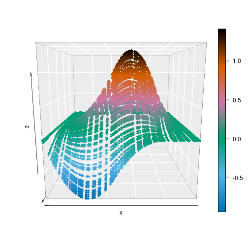

## Application of \(\texttt{glober.2d}\) to estimate \(f_2\)

The \(\texttt{glober.2d}\) function of the \(\texttt{glober}\) package is applied by using the following arguments: the input values \((x_i)_{1 \leq i \leq n}\) ($\texttt{x}$), the corresponding \((Y_i)_{1 \leq i \leq n}\) ($\texttt{y}$), \(N\) input values \(\{x_1, \ldots, x_N\}\) for which \(f_2\) has to be estimated ($\texttt{xpred}$) and the order of the B-spline basis used to estimate \(f_2\) ($\texttt{ord}$).

```r
res = glober.2d(x = x_2D, y = y_2D, xpred = xpred_2D, ord = 3, parallel = FALSE)
```

Additional arguments can also be used in this function:

- \(\texttt{parallel}\): Logical, if TRUE then a parallelized version of the code is used. Default is FALSE.
- \(\texttt{nb.Cores}\): Numerical, it corresponds to the number of cores used for parallelization, if parallel is set to TRUE.

Outputs:

- \(\texttt{festimated}\): the estimated values of \(f_2\).
- \(\texttt{knotSelec}\): the selected knots used in the definition of the B-splines of the GLOBER estimator.
- \(\texttt{rss}\): Residual sum-of-squares (RSS) of the model defined as: \(\sum_{k=1}^n (Y_i - \widehat{f_2}(x_i))^2\), where \(\widehat{f_2}\) is the estimator of \(f_2\).
- \(\texttt{rsq}\): R-squared of the model, calculated as \(1 - RSS/TSS\) where TSS is the total sum-of-squares of the model defined as \(\sum_{k=1}^n (Y_i - \bar{Y})^2\).

Thus, we can print the estimated values corresponding to the input values \(\{x_1, \ldots, x_N\}\):

```r
fhat_2D = res$festimated
head(fhat_2D)
```

```
## [1] -0.001507484 -0.001594391 -0.001764006 -0.002086438 -0.002313565
## [6] -0.002730025
```

The value of the Residual Sum-of-square:

```r
res$rss
```

[output not shown]

The value of the R-squared:

```r
res$rsq
```

```
## [1] 0.9988952
```

We can get the set of estimated knots for each dimension \(\mathbf{\widehat{t}_1}\) and \(\mathbf{\widehat{t}_2}\):

```r
knots.set = res$Selected.knots
print('For the first dimension:')
```

```
## [1] "For the first dimension:"
```

```r
print(knots.set[[1]])
```

```
## [1] 0.255 0.540
```

```r
print('For the second dimension:')
```

```
## [1] "For the second dimension:"
```

```r
print(knots.set[[2]])
```

```
## [1] 0.650 0.655
```

As for \(f_1\), we can visualize the corresponding estimation of \(f_2\):

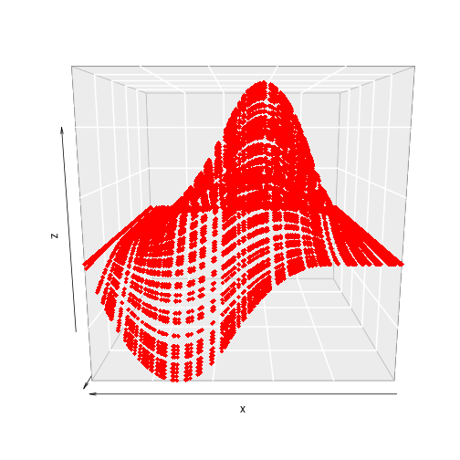

```r
scatter3D(xpred_2D[,1], xpred_2D[,2], f_2D, bty = "g", pch = 18, col = 'red',
          theta = 180, phi = 10)
```

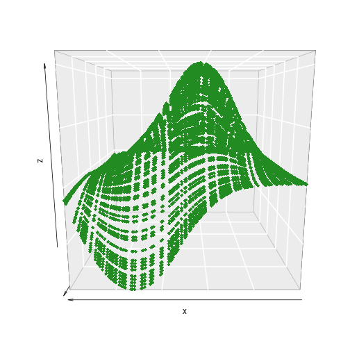

```r
scatter3D(xpred_2D[,1], xpred_2D[,2], fhat_2D, bty = "g", pch = 18, col = 'forestgreen',
          theta = 180, phi = 10)
```

The red surface describes the true underlying function \(f_2\) to estimate and the green surface corresponds to the estimation with GLOBER.

**References**

[1] Savino, M. E. and Lévy-Leduc, C. A novel approach for estimating functions in the multivariate setting based on an adaptive knot selection for B-splines with an application to a chemical system used in geoscience (2023), arXiv:2306.00686.

[2] Tibshirani, R. J. and J. Taylor (2011). The solution path of the generalized lasso. The Annals of Statistics 39(3), 1335 – 1371.